# Chapter 4 Coding Set

**Remember to save a copy of this template BEFORE YOU START WORKING :)**

Work completed by Isaiah Garrison.

If you start to struggle with a problem for an extended period of time, remember you can go comment on two other submissions now (seeing other student work helps), or you can post in our discussion forum for questions, which can also earn you extra credit.

## Imports

**If your program requires additional modules, external resources, or files, use this cell to set them up**

```python
# configure your environment

# you can uncomment this code to make use of files stored in your Google Drive
# from google.colab import drive
# drive.mount('/content/drive')

# you can uncomment the following line of code to use the pandas library
# import pandas as pd
```

## Algorithm Workbench

### Problem 3

#### Question Text

Write a loop that displays the following set of numbers: 0, 10, 20, 30, 40, 50... 1000

#### High-Level Overview

My general approach to this question was simple. I knew I had to make a for loop so that it can iteratate each number and so I only had to figure out how to fill it in. I remembered the ch. 4 notes and how it said the roles of the first, decond, and third numbers. Once I had solved it, I double checked and made no mistakes.

```python
# add your code to this cell
# remember to include comments like this one for most of your code
# remember to "Run cell" once you're done, excecuting your code so the output is displayed below

# Making the for loop
for i in range(0, 1010, 10):
    print(i)
```

```
0
10
20
30
40
50
60
70
80
90
100
110
120
130
140
150
160
170
180
190
200
210
220
230
240
250
260
270
280
290
300
310
320
330
340
350
360
370
380
390
```

[output cut: 46 more lines]

```
860
870
880
890
900
910
920
930
940
950
960
970
980
990
1000
```

### Problem 8

#### Question Text

Write code that prompts the user to enter a positive nonzero number and validates the input.

#### High-Level Overview

I had to break this down into sepa=earate stages of three. I first obviously asked the user for the number to start. After I got the number, I had to make sure it wasn't negative so I used while negative to do that which is straight forward and knew it asks the user to enter a new number so it doesn't become an infinite. Lastly, I used print at the end to show everything works as expected.

```python
# add your code to this cell
# remember to include comments like this one for most of your code
# remember to "Run cell" once you're done, excecuting your code so the output is displayed below

# Asking user for a number
user_number = float(input("Please enter a number"))

# Validate user input
while user_number < 0:
    user_number = float(input("Do not enter negative numbers. Please enter a number again:  "))

# Continuing once validated
print("You have a valid number")
```

```
You have a valid number
```

## Programming Exercises

### Problem 1

#### Question Text

A bug collector collects bugs every day for five days. Write a program that keeps a running total of the number of bugs collected during the five days. The loop should ask for the number of bugs collected for each day, and when the loop is finished, the program should display the total number of bugs collected.

#### High-Level Overview

I tried to think a bit outside the box on this one. Since it was 5 days, I made the loop around the days variable and add a day each time. I also had to think of how I were to get the total and I thought of adding another variable called total to dump the number too. The only thing I really messed up on was forgetting to set the total variable to 0 at first. In the end, it worked out.

```python
# add your code to this cell
# remember to include comments like this one for most of your code
# remember to "Run cell" once you're done, excecuting your code so the output is displayed below

# Setting the days
days = 1

# Setting the total amount
total = 0

# Making the loop for bugs collected
while days < 6:
    bugs = float(input(f"please enter the number of bugs collected on day {days}"))
    total += bugs
    days += 1

# Display the total
print (f"The total amount of bugs collected is {total}")
```

```
The total amount of bugs collected is 17.0
```

### Problem 4

#### Question Text

The distance a vehicle travels can be calculated as follows: distance = speed x time For example, if a train travels 40 miles per hour for three hours, the distance traveled is 120 miles. Write a program that asks the user for the speed of a vehicle (in miles per hour) and the number of hours it has traveled. It should then use a loop to display the distance the vehicle has traveled for each hour of that time period. Here is an example of the desired output:

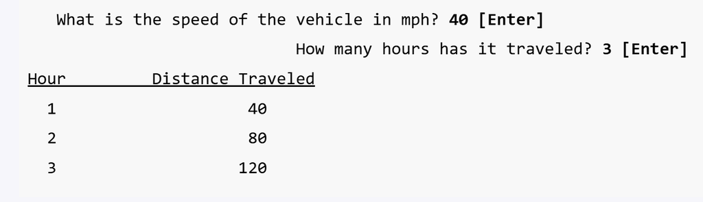

#### High-Level Overview

```python
# add your code to this cell
# remember to include comments like this one for most of your code
# remember to "Run cell" once you're done, excecuting your code so the output is displayed below

# Ask user for speed of the vehicle in mph
speed = float(input("What is the speed of the vehicle in mph?  "))

# Ask user for hours traveled
hours = int(input("How many hours has it traveled?  "))

# Calculate and display using loop
for hours in range(hours + 1):
    distance = speed * hours
    print(f"On hour {hours} your distance is {distance} miles")
```

```
On hour 0 your distance is 0.0 miles
On hour 1 your distance is 34.0 miles
On hour 2 your distance is 68.0 miles
On hour 3 your distance is 102.0 miles
```

### Problem 12

#### Question Text

Write a program that predicts the approximate size of a population of organisms. The application should prompt the user to enter the starting number of organisms, the average daily population increase (as a percentage), and the number of days the organisms will be left to multiply. For example, assume the user enters the following values: Starting number of organisms: 2 Average daily increase: 30% Number of days to multiply: 10 The program should display the following table of data:

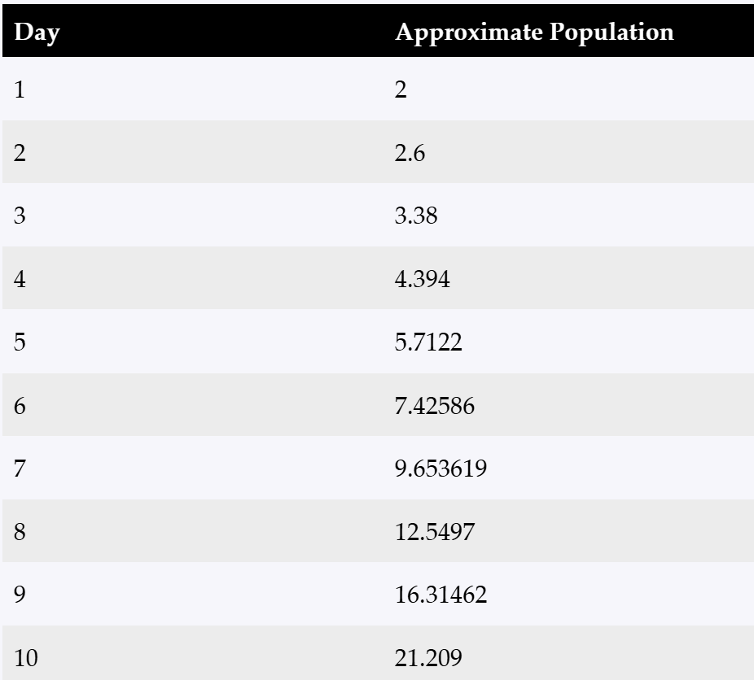

#### High-Level Overview

This one wasn't really as easy. The math was the hardest part, especially with the percentage bit added in. It took me a bit to figure out a way which was to add the percentage variable and use that. I had a bit of issues with the format at the end, I realized i forgot to add +1 to the end range and add 1 as the start of the range in order to fit everything well like the example.

```python
# add your code to this cell
# remember to include comments like this one for most of your code
# remember to "Run cell" once you're done, excecuting your code so the output is displayed below

# ask user for starting number of organisms
organisms = int(input("Please enter starting number of organisms:  "))

# ask user for average daily population increase
increase = float(input("Please enter the average daily population increase (as a percentage):  "))

# ask for number of days the organisms will be left to multiply
days = int(input("Please enter the amount of days the organisms will be left to multiply:  "))

# calculating and displaying the data
for days in range(1, days + 1):
    print(f"On day {days}, you will have approximately {organisms} organisms")
    percent = organisms * (increase/100)
    organisms += percent
```

```
On day 1, you will have approximately 2 organisms
On day 2, you will have approximately 2.6 organisms
On day 3, you will have approximately 3.38 organisms
On day 4, you will have approximately 4.394 organisms
On day 5, you will have approximately 5.7122 organisms
On day 6, you will have approximately 7.42586 organisms
On day 7, you will have approximately 9.653618 organisms
On day 8, you will have approximately 12.5497034 organisms
On day 9, you will have approximately 16.31461442 organisms
On day 10, you will have approximately 21.208998746000002 organisms
```

### Problem 14

#### Question Text

Write a program that uses nested loops to draw this pattern:

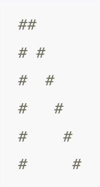

#### High-Level Overview

This one had to of been the hardest question I've ever had in this class. To me it was unneccesary to make this into a nested loop and a regular loop would have been simpler. Regardless, I had to figure it out and starting thinking in rows and lines. I had a lot of trouble trying to think of where the loops would be and how they would build off each other.

```python
# add your code to this cell
# remember to include comments like this one for most of your code
# remember to "Run cell" once you're done, excecuting your code so the output is displayed below

# how many rows there will be
rows = 5

# Making the nested loop
for r in range(rows):
    line = "#"
    for s in range(r):
        line += " "
    line += "#"
    print (line)
```

```
##
# #
#  #
#   #
#    #
```

## Helpful Checks

1. Did you comment every line of code with meaningful information that will help others reading your code?
2. Did you use appropriate names for your variables, functions, and/or classes?
3. Did you include a high-level explanation for each solution?
4. Did you run each cell that includes a final solution so the output is saved and easily viewed by others?
5. Are you sharing an editable link (i.e., Share > Anyone with the link > Editor) if using Colaboratory, or did you make more than ten commits if using GitHub?
6. Did you remember to comment on the submissions of two other students?